# Analisis Korespondensi

Zanira Husna

2025-12-16

```r
library(factoextra)
library(ggplot2)
library(FactoMineR)
library(gplots)
```

# Data

Data bangkitan dengan 2 peubah kategori, peubah pertama kategori1 dengan 5 taraf A,B,C,D,E dan peubah kedua kategori2 dengan 7 taraf 1,2,3,4,5,6,7. data memiliki panjang n=1000 amatan.

```r
set.seed(1097)  # NIM

n <- 1000

kategori1 <- factor(
  sample(c("A", "B", "C", "D", "E"), n, replace = TRUE)
)

kategori2 <- factor(
  sample(c("1", "2", "3","4","5","6","7"), n, replace = TRUE)
)

data <- data.frame(kategori1, kategori2)

head(data)
```

```
##   kategori1 kategori2
## 1         C         3
## 2         C         5
## 3         A         6
## 4         E         3
## 5         B         5
## 6         C         1
```

# Manual

## Tabel Kontingensi

```r
konti <- table(data$kategori1, data$kategori2)
konti
```

```
##
##      1  2  3  4  5  6  7
##   A 30 30 18 36 26 25 31
##   B 27 31 31 36 26 23 29
##   C 21 31 30 27 23 41 40
##   D 24 30 33 16 39 32 28
##   E 24 20 25 35 26 26 30
```

Dari tabel kontingensi dapat dilihat frekuensi terbanyak pada C-6 sebanyak 41 amatan. Kombinasi D-4 memiliki frekuensi yang paling sedikit dengan 16 amatan. Frekuensi tidak jauh berbeda, cenderung berkisar pada nilai 20-30an.

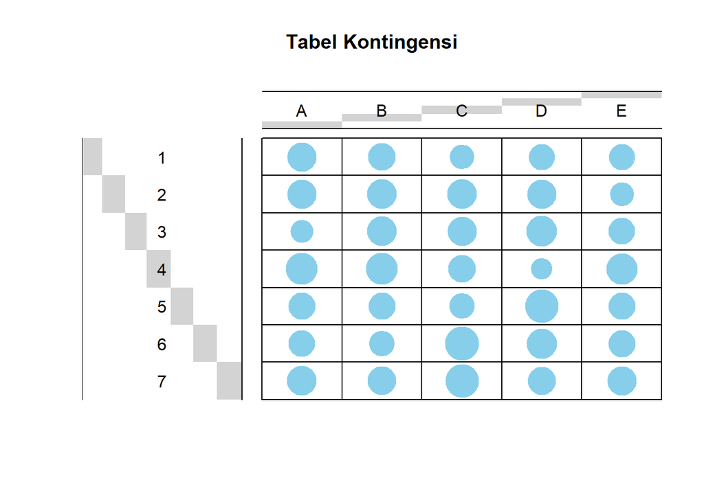

```r
balloonplot(konti, main ="Tabel Kontingensi", xlab ="", ylab="", label = FALSE, show.margins = FALSE)
```

semakin besar lingkaran menunjukkan semakin besar pula nilai yang direpresentasikan

## Tabel Korespondensi

```r
kores <- konti/n
kores
```

```
##
##         1     2     3     4     5     6     7
##   A 0.030 0.030 0.018 0.036 0.026 0.025 0.031
##   B 0.027 0.031 0.031 0.036 0.026 0.023 0.029
##   C 0.021 0.031 0.030 0.027 0.023 0.041 0.040
##   D 0.024 0.030 0.033 0.016 0.039 0.032 0.028
##   E 0.024 0.020 0.025 0.035 0.026 0.026 0.030
```

## Vektor kolom dan baris

```r
kolom <- colSums(kores)
kolom
```

```
##     1     2     3     4     5     6     7
## 0.126 0.142 0.137 0.150 0.140 0.147 0.158
```

```r
baris<- rowSums(kores)
baris
```

```
##     A     B     C     D     E
## 0.196 0.203 0.213 0.202 0.186
```

hasil dari vektor menunjukkan persentase munculnya tiap taraf kategori peubah. baris merepresentasikan kategori1 dan kolom untuk kategori2. pada kategori1 C memiliki nilai terbesar, artinya C yang paling banyak muncul (modus). begitu juga dengan kategori2 dengan nilai terbesar pada 7.

## Matriks kolom dan baris

```r
matriks_kol <- diag(kolom)
matriks_kol
```

```
##       [,1]  [,2]  [,3] [,4] [,5]  [,6]  [,7]
## [1,] 0.126 0.000 0.000 0.00 0.00 0.000 0.000
## [2,] 0.000 0.142 0.000 0.00 0.00 0.000 0.000
## [3,] 0.000 0.000 0.137 0.00 0.00 0.000 0.000
## [4,] 0.000 0.000 0.000 0.15 0.00 0.000 0.000
## [5,] 0.000 0.000 0.000 0.00 0.14 0.000 0.000
## [6,] 0.000 0.000 0.000 0.00 0.00 0.147 0.000
## [7,] 0.000 0.000 0.000 0.00 0.00 0.000 0.158
```

```r
matriks_bar <- diag(baris)
matriks_bar
```

```
##       [,1]  [,2]  [,3]  [,4]  [,5]
## [1,] 0.196 0.000 0.000 0.000 0.000
## [2,] 0.000 0.203 0.000 0.000 0.000
## [3,] 0.000 0.000 0.213 0.000 0.000
## [4,] 0.000 0.000 0.000 0.202 0.000
## [5,] 0.000 0.000 0.000 0.000 0.186
```

## Analisis profil baris

```r
R <- solve(matriks_bar)%*%kores
rownames(R) <- rownames(kores)
R
```

```
##
##              1         2          3          4         5         6         7
##   A 0.15306122 0.1530612 0.09183673 0.18367347 0.1326531 0.1275510 0.1581633
##   B 0.13300493 0.1527094 0.15270936 0.17733990 0.1280788 0.1133005 0.1428571
##   C 0.09859155 0.1455399 0.14084507 0.12676056 0.1079812 0.1924883 0.1877934
##   D 0.11881188 0.1485149 0.16336634 0.07920792 0.1930693 0.1584158 0.1386139
##   E 0.12903226 0.1075269 0.13440860 0.18817204 0.1397849 0.1397849 0.1612903
```

pada kolom “1” dan “2”, nilai A memiliki nilai tertinggi (0,15) artinya banyak amatan “1” dan juga amatan “2” yang memiliki nilai A. kolom “3” dan “5” D memiliki nilai tertinggi (0.16 dan 0.19), banyak amatan “3” dan amatan “5” yang memiliki nilai D. begitupun dengan kolom 4 dengan E, kolom 6 dan 7 dengan C.

```r
mass_c <- colSums(R)
mass_c
```

```
##         1         2         3         4         5         6         7
## 0.6325018 0.7073522 0.6831661 0.7551539 0.7015674 0.7315406 0.7887180
```

nilai massa setiap kolom, dengan nilai yang terbesar pada 7. hasil ini sama dengan sebelumnya yang menunjukkan 7 sebagai modus

## Analisis profil kolom

```r
C <- kores%*%solve(matriks_kol)
colnames(C) <- colnames(kores)
C
```

```
##
##             1         2         3         4         5         6         7
##   A 0.2380952 0.2112676 0.1313869 0.2400000 0.1857143 0.1700680 0.1962025
##   B 0.2142857 0.2183099 0.2262774 0.2400000 0.1857143 0.1564626 0.1835443
##   C 0.1666667 0.2183099 0.2189781 0.1800000 0.1642857 0.2789116 0.2531646
##   D 0.1904762 0.2112676 0.2408759 0.1066667 0.2785714 0.2176871 0.1772152
##   E 0.1904762 0.1408451 0.1824818 0.2333333 0.1857143 0.1768707 0.1898734
```

pada baris A, B, dan E, nilai “4” memiliki nilai tertinggi (0.24 dan 0,23) artinya banyak amatan A, B dan juga amatan E yang memiliki nilai “4”. pada baris C, “6” memiliki nilai tertinggi (0.27) yang berarti banyak amatan C yang memiliki nilai “6”. begitupun dengan kolom D dengan “5”. ini menunjukkan hasil yang cukup berbeda dengan analisis baris

```r
mass_r <- rowSums(C)
mass_r
```

```
##        A        B        C        D        E
## 1.372735 1.424594 1.480316 1.422760 1.299595
```

Nilai massa kategori1 menunjukkan nilai C merupakan yang terbesar. Hasil ini juga masih sama dengan hasil modus awal kategori1.

## Menentukan koordinat profil baris dan kolom

```r
Prc <- kores - baris%*%t(kolom)
Prc
```

```
##
##             1         2         3         4         5         6         7
##   A  0.005304  0.002168 -0.008852  0.006600 -0.001440 -0.003812  0.000032
##   B  0.001422  0.002174  0.003189  0.005550 -0.002420 -0.006841 -0.003074
##   C -0.005838  0.000754  0.000819 -0.004950 -0.006820  0.009689  0.006346
##   D -0.001452  0.001316  0.005326 -0.014300  0.010720  0.002306 -0.003916
##   E  0.000564 -0.006412 -0.000482  0.007100 -0.000040 -0.001342  0.000612
```

```r
Z <- diag(1/sqrt(diag(matriks_bar)))%*%Prc%*%diag(1/sqrt(diag(matriks_kol)))
Z
```

```
##              [,1]         [,2]         [,3]        [,4]          [,5]
## [1,]  0.033751277  0.012995323 -0.054019814  0.03849198 -0.0086930152
## [2,]  0.008891321  0.012804639  0.019122568  0.03180529 -0.0143550044
## [3,] -0.035636005  0.004335482  0.004794395 -0.02769298 -0.0394939485
## [4,] -0.009101347  0.007770269  0.032015862 -0.08215135  0.0637463148
## [5,]  0.003684150 -0.039454166 -0.003019467  0.04250659 -0.0002478789
##              [,6]          [,7]
## [1,] -0.022457747  0.0001818417
## [2,] -0.039601616 -0.0171643476
## [3,]  0.054755845  0.0345924819
## [4,]  0.013382121 -0.0219198943
## [5,] -0.008115913  0.0035699851
```

```r
Du <- diag(sqrt(eigen(Z %*% t(Z))$values))[1:2,1:2]
Du
```

```
##           [,1]       [,2]
## [1,] 0.1390767 0.00000000
## [2,] 0.0000000 0.09574709
```

```r
U <- eigen(Z %*% t(Z))$vectors
U
```

```
##            [,1]         [,2]        [,3]        [,4]       [,5]
## [1,] -0.4761583 -0.117247558  0.74956598  0.04095229 -0.4427189
## [2,] -0.2712585 -0.258292015 -0.44171179 -0.67940764 -0.4505552
## [3,]  0.2760223  0.829414112  0.04045437 -0.14576480 -0.4615192
## [4,]  0.7348374 -0.481241501  0.12008416  0.10954648 -0.4494441
## [5,] -0.2889944  0.004134491 -0.47642920  0.70956350 -0.4312772
```

```r
A <- (sqrt(matriks_bar) %*% U)[,1:2]
A
```

```
##            [,1]         [,2]
## [1,] -0.2108043 -0.051907707
## [2,] -0.1222169 -0.116374814
## [3,]  0.1273896  0.382790563
## [4,]  0.3302683 -0.216291154
## [5,] -0.1246367  0.001783112
```

```r
V <- eigen(t(Z) %*% Z)$vectors
V
```

```
##             [,1]        [,2]        [,3]        [,4]       [,5]        [,6]
## [1,] -0.25936643  0.32811066 -0.30411822 -0.04538232 -0.6524002  0.00000000
## [2,]  0.06217723  0.05365797 -0.42712267  0.75765383 -0.2165482  0.06076362
## [3,]  0.33260231  0.10495172  0.77377193  0.30645605 -0.4142196  0.10502141
## [4,] -0.77116894 -0.04191552  0.29257489 -0.10889405 -0.2525025 -0.09265477
## [5,]  0.31670838  0.61315930 -0.10682485 -0.46291861 -0.1445430  0.20882670
## [6,]  0.35037266 -0.54104602 -0.14862089 -0.28902978 -0.4877342 -0.45017794
## [7,] -0.02172597 -0.45606723 -0.08517955 -0.14246420 -0.1826693  0.85464882
##             [,7]
## [1,]  0.55217660
## [2,] -0.43150478
## [3,]  0.05581362
## [4,] -0.48346783
## [5,] -0.48324426
## [6,] -0.19579823
## [7,] -0.01365142
```

```r
B <- (sqrt(matriks_kol) %*% V)[,1:2]
B
```

```
##              [,1]        [,2]
## [1,] -0.092065950  0.11646773
## [2,]  0.023430176  0.02021987
## [3,]  0.123107791  0.03884632
## [4,] -0.298672447 -0.01623381
## [5,]  0.118501424  0.22942320
## [6,]  0.134334907 -0.20744018
## [7,] -0.008635903 -0.18128314
```

### koordinas baris

```r
rows <- solve(matriks_bar)%*%A%*%Du
rows
```

```
##             [,1]          [,2]
## [1,] -0.14958150 -0.0253572028
## [2,] -0.08373170 -0.0548894064
## [3,]  0.08317807  0.1720708054
## [4,]  0.22738933 -0.1025210299
## [5,] -0.09319389  0.0009178911
```

### koordinas kolom

```r
cols <- solve(matriks_kol)%*%B%*%Du
cols
```

```
##              [,1]        [,2]
## [1,] -0.101620894  0.08850354
## [2,]  0.022947835  0.01363376
## [3,]  0.124973948  0.02714906
## [4,] -0.276922611 -0.01036227
## [5,]  0.117719946  0.15690431
## [6,]  0.127094297 -0.13511424
## [7,] -0.007601603 -0.10985653
```

## visualisasi berdasarkan koordinat profil baris dan kolom

```r
row_df <- data.frame(rows)
col_df <- data.frame(cols)
colnames(row_df) <- c("Dim.1", "Dim.2")
rownames(row_df) <- rownames(konti)
colnames(col_df) <- c("Dim.1", "Dim.2")
rownames(col_df) <- colnames(konti)
row_df["Var"] <- "kategori1"
row_df["Size"] <- 2
col_df["Var"] <- "kategori2"
col_df["Size"] <- 2
ca.plot.df <- rbind(col_df, row_df)
ca.plot.df["Label"] <- rownames(ca.plot.df)
ca.plot.df
```

```
##          Dim.1         Dim.2       Var Size Label
## 1 -0.101620894  0.0885035395 kategori2    2     1
## 2  0.022947835  0.0136337609 kategori2    2     2
## 3  0.124973948  0.0271490636 kategori2    2     3
## 4 -0.276922611 -0.0103622664 kategori2    2     4
## 5  0.117719946  0.1569043110 kategori2    2     5
## 6  0.127094297 -0.1351142366 kategori2    2     6
## 7 -0.007601603 -0.1098565350 kategori2    2     7
## A -0.149581499 -0.0253572028 kategori1    2     A
## B -0.083731702 -0.0548894064 kategori1    2     B
## C  0.083178072  0.1720708054 kategori1    2     C
## D  0.227389327 -0.1025210299 kategori1    2     D
## E -0.093193893  0.0009178911 kategori1    2     E
```

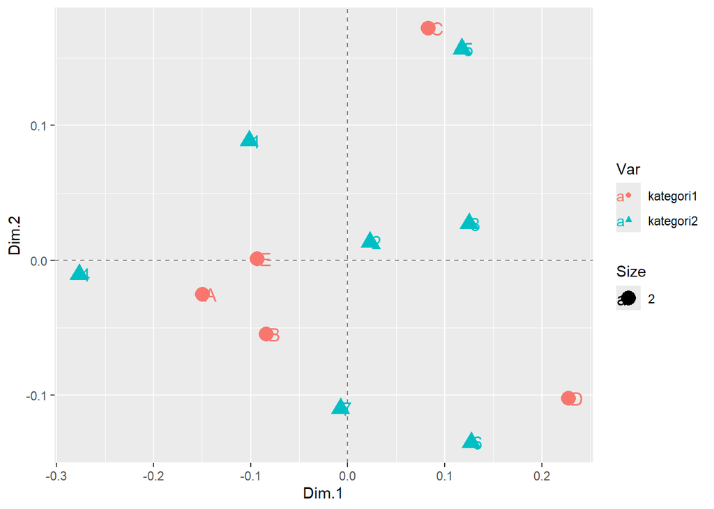

```r
ggplot(ca.plot.df, aes(x = Dim.1, y = Dim.2,
                       col = Var, shape = Var,
                       label = Label, size = Size)) +
  geom_vline(xintercept = 0, lty = "dashed", alpha = .5) +
  geom_hline(yintercept = 0, lty = "dashed", alpha = .5) +
  geom_point() + geom_text(check_overlap = T, hjust=-0.15)
```

# Pemodelan

```r
chisq <- chisq.test(konti)
chisq
```

```
##
##  Pearson's Chi-squared test
##
## data:  konti
## X-squared = 33.915, df = 24, p-value = 0.08619
```

dari hasil uji Khi-kuadrat, diperoleh bahwa kedua peubah tidak terlalu saling terkait.

```r
model <- CA(konti, graph = F)
print(model)
```

```
## **Results of the Correspondence Analysis (CA)**
## The row variable has  5  categories; the column variable has 7 categories
## The chi square of independence between the two variables is equal to 33.91524 (p-value =  0.08618676 ).
## *The results are available in the following objects:
##
##    name              description
## 1  "$eig"            "eigenvalues"
## 2  "$col"            "results for the columns"
## 3  "$col$coord"      "coord. for the columns"
## 4  "$col$cos2"       "cos2 for the columns"
## 5  "$col$contrib"    "contributions of the columns"
## 6  "$row"            "results for the rows"
## 7  "$row$coord"      "coord. for the rows"
## 8  "$row$cos2"       "cos2 for the rows"
## 9  "$row$contrib"    "contributions of the rows"
## 10 "$call"           "summary called parameters"
## 11 "$call$marge.col" "weights of the columns"
## 12 "$call$marge.row" "weights of the rows"
```

## akar ciri

```r
eig.val <- get_eigenvalue(model)
eig.val
```

```
##        eigenvalue variance.percent cumulative.variance.percent
## Dim.1 0.019342341        57.031413                    57.03141
## Dim.2 0.009167505        27.030635                    84.06205
## Dim.3 0.003154807         9.302033                    93.36408
## Dim.4 0.002250588         6.635920                   100.00000
```

## persentase keragaman

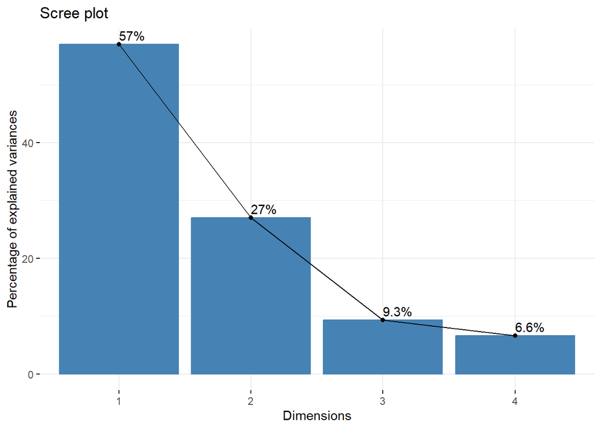

```r
fviz_screeplot(model, addlabels = TRUE)
```

2 dimensi cukup menggambarkan keragaman pada data dengan 84%, sudah melebihi batas 70%

## analisis dan visualisasi profil baris

```r
row <- get_ca_row(model)
row
```

```
## Correspondence Analysis - Results for rows
##  ===================================================
##   Name       Description
## 1 "$coord"   "Coordinates for the rows"
## 2 "$cos2"    "Cos2 for the rows"
## 3 "$contrib" "contributions of the rows"
## 4 "$inertia" "Inertia of the rows"
```

```r
row$coord
```

```
##         Dim 1         Dim 2        Dim 3        Dim 4
## A -0.14958150  0.0253572028  0.095097307 -0.004388318
## B -0.08373170  0.0548894064 -0.055065217  0.071536949
## C  0.08317807 -0.1720708054  0.004923365  0.014983417
## D  0.22738933  0.1025210299  0.015007087 -0.011563006
## E -0.09319389 -0.0009178911 -0.062048072 -0.078051779
```

```r
row$contrib
```

```
##       Dim 1        Dim 2      Dim 3     Dim 4
## A 22.672677  1.374698990 56.1849152  0.167709
## B  7.358120  6.671476499 19.5109302 46.159474
## C  7.618830 68.792776904  0.1636556  2.124738
## D 53.998598 23.159338205  1.4420204  1.200043
## E  8.351776  0.001709402 22.6984786 50.348036
```

Untuk memetakan menjadi dua dimensi, maka hanya perlu melihat Dim 1 dan Dim 2 nya saja. profil baris yang berkontribusi paling banyak kepada Dim 1 dan Dim 2 adalah baris yang paling penting dalam menjelaskan keragaman data. Dalam hal ini, C dan D dianggap sebagai kategori yang menyumbang keragaman paling besar.

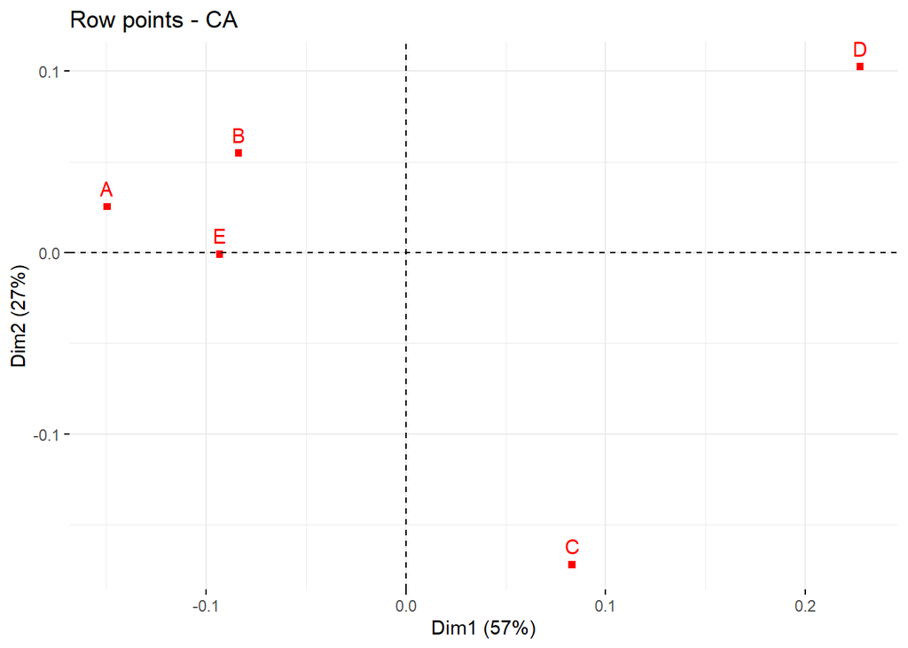

```r
fviz_ca_row(model, col.row="RED", shape.row = 15)
```

profil A, B dan E dapat dikatakan mirip dikarenkan posisi ketiganya berdekatan, namun ketiganya berkorelasi negatif C dan D

## analisis dan visualisasi profil kolom

```r
col <- get_ca_col(model)
col
```

```
## Correspondence Analysis - Results for columns
##  ===================================================
##   Name       Description
## 1 "$coord"   "Coordinates for the columns"
## 2 "$cos2"    "Cos2 for the columns"
## 3 "$contrib" "contributions of the columns"
## 4 "$inertia" "Inertia of the columns"
```

```r
col$coord
```

```
##          Dim 1       Dim 2       Dim 3       Dim 4
## 1 -0.101620894  0.08850354  0.04812199 -0.00606526
## 2  0.022947835  0.01363376  0.06366413  0.09538381
## 3  0.124973948  0.02714906 -0.11741919  0.03927859
## 4 -0.276922611 -0.01036227 -0.04243047 -0.01333849
## 5  0.117719946  0.15690431  0.01603595 -0.05869331
## 6  0.127094297 -0.13511424  0.02177246 -0.03576283
## 7 -0.007601603 -0.10985653  0.01203631 -0.01700299
```

```r
col$contrib
```

```
##         Dim 1      Dim 2      Dim 3      Dim 4
## 1  6.72709453 10.7656605  9.2487890  0.2059555
## 2  0.38660080  0.2879178 18.2433775 57.4039322
## 3 11.06242944  1.1014864 59.8722997  9.3915309
## 4 59.47015354  0.1756910  8.5600064  1.1857913
## 5 10.03041972 37.5964330  1.1411548 21.4293638
## 6 12.27610019 29.2730796  2.2088170  8.3538214
## 7  0.04720178 20.7997318  0.7255556  2.0296047
```

profil kolom yang berkontribusi paling banyak kepada Dim 1 dan Dim 2 adalah kolom yang paling penting dalam menjelaskan keragaman data. Dalam hal ini, “4” dan “5” dianggap sebagai kategori yang menyumbang keragaman paling besar.

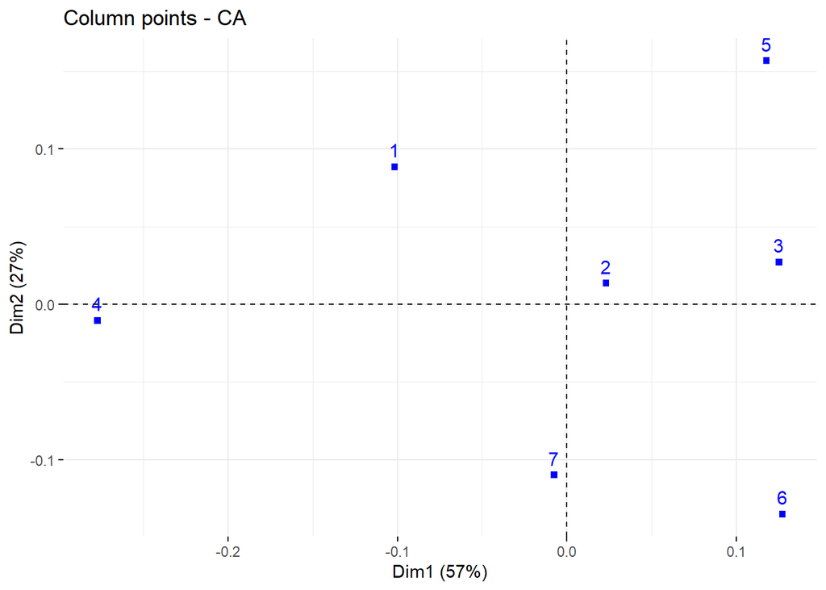

```r
fviz_ca_col(model, col.col="BLUE", shape.col = 15)
```

berbeda dengan kategori1, pada kategori2 tidak ada titik yang berdekatan sehingga tidak ada yang memiliki profil serupa

## pembentukan plot korespondensi

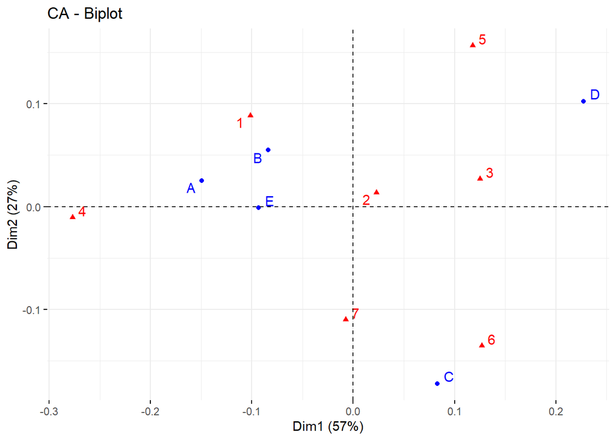

```r
fviz_ca_biplot(model, repel = TRUE)
```